# **Physics-informed neural network (PINN) for Heat Equation**

## Problem

We are going to assume we have a uniform bar of length $L$, where one end is placed on the origin and the other at $x = L$.

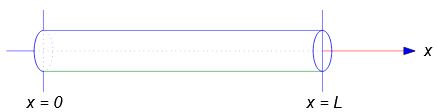

Here the change in temperature is the partial differential equation \begin{equation} u_t = a^2 u_{xx},\quad 0 < x < L,\ t > 0, \end{equation} where $a$ is a constant.

This is a *homogeneous* initial boundary value problem \begin{cases} u_t = a^2 u_{xx},\quad 0 < x < L,\ t > 0,\\[1em] u(0,t) = 0,\quad u(L,t)=0,\quad t > 0,\\[1em] u(x,0) = \varphi(x), \quad 0\leq x\leq L. \end{cases}

This can be solved by the standard Fourier method, which we will not be going into.

\begin{align} u(x,t) &= \sum_{n=1}^{\infty} \alpha_n e^{-n^2 \pi^2 a^2 t / L^2}\sin\frac{n\pi x}{L} \\ \alpha_n &= \frac{2}{L} \int_0^L \varphi(x)\sin\frac{n\pi x}{L}dx \end{align}

We can take $\varphi$ as a function that reiles on the length of the rod \begin{equation} \varphi(x) = x(x^2 -3Lx+2L^2). \end{equation}

The parameters $a$ and $L$ are going to be 1 for now.

```python
import numpy as np
import matplotlib.pyplot as plt
import torch
import torch.nn as nn
```

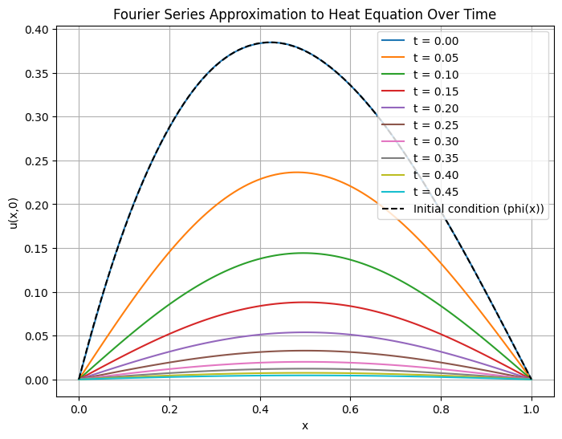

```python
# Parameters
L = 1  # Length of the domain
a = 1  # Thermal diffusivity
n_terms = 10  # Number of terms in the Fourier series

# Initial condition function (for example, a sine wave)
def phi(x,L):
    f = x*(x**2-3*L*x+2*L**2)
    return f

# Fourier series approximation
def fourier_series(x, t, n_terms, L, a):
    u = np.zeros_like(x)
    for n in range(1, n_terms + 1):
        a_n = 2 / L * np.trapz(phi(x,L) * np.sin(n * np.pi * x / L), x)  # Fourier coefficient
        u += a_n * np.sin(n * np.pi * x / L) * np.exp((-a**2 * (n * np.pi )**2 * t)/ L)
    return u

# Define the spatial domain and time
x = np.linspace(0, L, 100)
time_steps = np.linspace(0, 0.45, 10)  # Time steps from t=0 to t=2, with 5 intervals

# Plot the Fourier series at different times
plt.figure(figsize=(8, 6))
for t in time_steps:
    u = fourier_series(x, t, n_terms, L, a)
    plt.plot(x, u, label=f't = {t:.2f}')

# Plot the exact initial condition
plt.plot(x, phi(x,L), 'k--', label='Initial condition (phi(x))')

# Labeling the plot
plt.title(f"Fourier Series Approximation to Heat Equation Over Time")
plt.xlabel('x')
plt.ylabel('u(x,0)')
plt.legend()
plt.grid(True)
plt.show()
```

Here we can see that the equation reaches zero very fast, by the time $t = 0.5$.

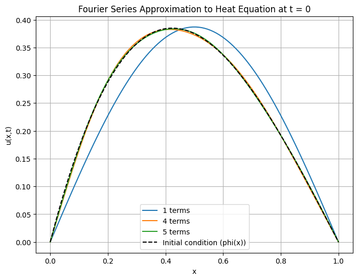

```python
# Define the spatial domain and time
x = np.linspace(0, L, 100)
t = 0  # Time at which to evaluate the solution

# Plot the Fourier series for different numbers of terms
plt.figure(figsize=(8, 6))
for n_terms in [1,4,5]:
    u = fourier_series(x, t, n_terms, L, a)
    plt.plot(x, u, label=f'{n_terms} terms')

# Plot the exact initial condition
plt.plot(x, phi(x,L), 'k--', label='Initial condition (phi(x))')

# Labeling the plot
plt.title(f"Fourier Series Approximation to Heat Equation at t = {t}")
plt.xlabel('x')
plt.ylabel('u(x,t)')
plt.legend()
plt.grid(True)
plt.show()
```

Here we can see that the approximation is accurate with 5 terms, so that is what we will be using.

\begin{align*} u(x,t) &= \frac{12L^3}{\pi^3}\sum_{n=1}^{\infty} \frac{1}{n^3} e^{-n^2 \pi^2 a^2 t/L^2} \sin \frac{n\pi x}{L}\\ &\approx \frac{12L^3}{\pi^3} \left( e^{-\pi^2 a^2 t/L^2}\sin\frac{\pi x}{L} + \frac{1}{8} e^{-4 \pi^2 a^2 t/L^2}\sin \frac{2\pi x}{L} + \frac{1}{27} e^{-9 \pi^2 a^2 t/L^2}\sin \frac{3\pi x}{L} + \frac{1}{64} e^{-16 \pi^2 a^2 t/L^2}\sin \frac{4\pi x}{L} + \frac{1}{125} e^{-25 \pi^2 a^2 t/L^2}\sin \frac{5\pi x}{L} \right). \end{align*}

## Task 1: train a PINN to simulate the system

```python
def exact_solution(a, L, x, t):
    u = ((12*L**3)/torch.pi**3)*(torch.exp(-torch.pi**2*a**2*t/L**2)*torch.sin(torch.pi*x/L) +
                             (1/8)*torch.exp(-4**torch.pi**2*a**2*t/L**2)*torch.sin(2*torch.pi*x/L) +
                             (1/27)*torch.exp(-9*torch.pi**2*a**2*t/L**2)*torch.sin(3*torch.pi*x/L)+
                             (1/64)*torch.exp(-16*torch.pi**2*a**2*t/L**2)*torch.sin(4*torch.pi*x/L)+
                             (1/125)*torch.exp(-25*torch.pi**2*a**2*t/L**2)*torch.sin(5*torch.pi*x/L))
    return u

class FCN(nn.Module):
    "Defines a fully-connected network in PyTorch"
    def __init__(self, N_INPUT, N_OUTPUT, N_HIDDEN, N_LAYERS):
        super().__init__()
        activation = nn.Tanh
        self.fcs = nn.Sequential(*[
                        nn.Linear(N_INPUT, N_HIDDEN),
                        activation()])
        self.fch = nn.Sequential(*[
                        nn.Sequential(*[
                            nn.Linear(N_HIDDEN, N_HIDDEN),
                            activation()]) for _ in range(N_LAYERS-1)])
        self.fce = nn.Linear(N_HIDDEN, N_OUTPUT)
    def forward(self, x):
        x = self.fcs(x)
        x = self.fch(x)
        x = self.fce(x)
        return x
```

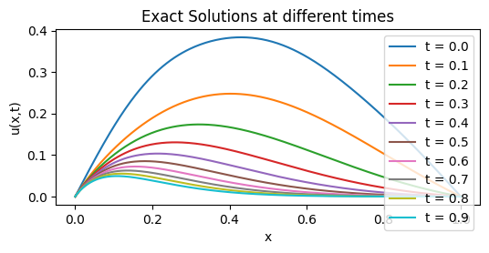

```python
# Plot exact solution for different values of t
plt.figure(figsize=(6, 2.5))
x_test = torch.linspace(0, L, 300).view(-1, 1)

for t_time in np.arange(0,1,0.1):

    t_test = torch.linspace(0, t_time, 300).view(-1, 1)
    u_exact = exact_solution(a, L, x_test, t_test)

    plt.plot(x_test[:, 0].cpu().detach().numpy(), u_exact.cpu().detach().numpy(), label=f"t = {t_time:.1f}")


plt.title("Exact Solutions at different times")
plt.xlabel("x")
plt.ylabel("u(x,t)")
plt.legend()
plt.show()
```

### Loss function

```python
device = torch.device("cuda" if torch.cuda.is_available() else "cpu")
device
```

```
device(type='cuda')
```

```python
# Define the PINN model
class PINN(nn.Module):
    def __init__(self, N_INPUT=2, N_OUTPUT=1, N_HIDDEN=32, N_LAYERS=3):
        super(PINN, self).__init__()
        activation = nn.Tanh
        self.fcs = nn.Sequential(
            nn.Linear(N_INPUT, N_HIDDEN),
            activation()
        )
        self.hidden_layers = nn.ModuleList([
            nn.Sequential(
                nn.Linear(N_HIDDEN, N_HIDDEN),
                activation()
            ) for _ in range(N_LAYERS - 1)
        ])
        self.fce = nn.Linear(N_HIDDEN, N_OUTPUT)

    def forward(self, x):
        x = self.fcs(x)
        for layer in self.hidden_layers:
            x = layer(x)
        x = self.fce(x)
        return x
```

```
Epoch 0: Loss = 0.130346
```

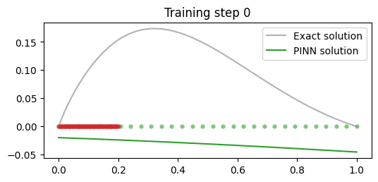

```
Epoch 5000: Loss = 0.000205
```

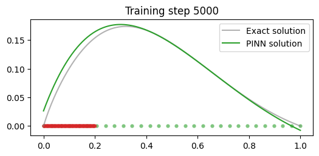

```
Epoch 10000: Loss = 0.000181
```

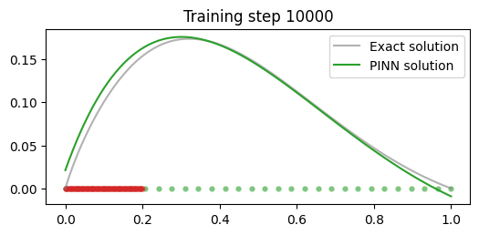

```
Epoch 15000: Loss = 0.000105
```

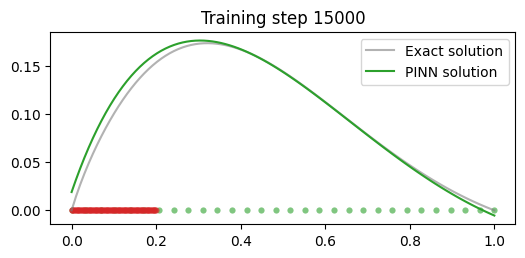

```python
import torch.autograd as autograd
torch.manual_seed(123)

# Define the PDE residual
def pde_residual(model, x, t, a):
    x = x.requires_grad_()
    t = t.requires_grad_()
    u = model(torch.cat([x, t], dim=1))  # Neural network output
    u_t = autograd.grad(u.sum(), t, create_graph=True)[0]  # Time derivative
    u_x = autograd.grad(u.sum(), x, create_graph=True)[0]  # First spatial derivative
    u_xx = autograd.grad(u_x.sum(), x, create_graph=True)[0]  # Second spatial derivative
    return u_t - a**2 * u_xx  # Residual of the PDE

# Model, parameters, and data
pinn = PINN(2,1,32,3).to(device)
a = 1.0  # Diffusion coefficient
L = 1.0  # Length of the spatial domain
t_time = 0.2 # Point in time for the graphs

# Training data
x_boundary = torch.tensor([[0.0], [L]], requires_grad=True).to(device)  # Boundary points
t_boundary = torch.linspace(0, t_time, 100).view(-1, 1).to(device)  # Time domain for boundary
x_initial = torch.linspace(0, L, 100).view(-1, 1).to(device)   # Spatial domain for initial condition
t_initial = torch.tensor([[0.0]], requires_grad=True).repeat(x_initial.size(0), 1).to(device)

# Define initial and boundary conditions
u_boundary = torch.zeros_like(t_boundary).to(device)  # Boundary condition: u(0,t) = u(L,t) = 0
u_initial = phi(x_initial,L).to(device)  # Initial condition: u(x,0) = φ(x)

# Loss function
loss_fn = nn.MSELoss()

# Test data for plotting
t_test = torch.linspace(0, t_time, 100).view(-1, 1).requires_grad_(True).to(device)  # Time domain
x_test = torch.linspace(0, L, 100).view(-1, 1).requires_grad_(True).to(device)
inputs_test = torch.cat([x_test, t_test], dim=1).to(device)
u_exact = exact_solution(a,L,x_test.cpu().detach(),t_test.cpu().detach())  # Exact solution

# Training loop
optimizer = torch.optim.Adam(pinn.parameters(), lr=0.001)
for epoch in range(15001):
    optimizer.zero_grad()

    # Boundary loss
    u_b1 = pinn(torch.cat([x_boundary[0].repeat(t_boundary.size(0), 1), t_boundary], dim=1))
    u_b2 = pinn(torch.cat([x_boundary[1].repeat(t_boundary.size(0), 1), t_boundary], dim=1))
    loss_boundary = loss_fn(u_b1, u_boundary) + loss_fn(u_b2, u_boundary)

    # Initial condition loss
    u_init = pinn(torch.cat([x_initial, t_initial], dim=1))
    loss_initial = loss_fn(u_init, u_initial)

    # PDE residual loss
    x_pde = torch.rand(1000, 1).to(device) * L  # Random points in spatial domain
    t_pde = torch.rand(1000, 1).to(device)      # Random points in temporal domain
    res_pde = pde_residual(pinn, x_pde, t_pde, a)
    loss_pde = loss_fn(res_pde, torch.zeros_like(res_pde).to(device))

    # Total loss
    loss = loss_boundary + loss_initial + loss_pde

    # Backpropagation
    loss.backward()
    optimizer.step()

    # Plot the result as training progresses
    if epoch % 5000 == 0:
        print(f"Epoch {epoch}: Loss = {loss.item():.6f}")
        u = pinn(inputs_test).detach()
        plt.figure(figsize=(6,2.5))
        plt.scatter(t_physics.cpu().detach()[:,0],
                    torch.zeros_like(t_physics)[:,0], s=20, lw=0, color="tab:green", alpha=0.6)
        plt.scatter(t_boundary.cpu().detach()[:,0],
                    torch.zeros_like(t_boundary.cpu().detach())[:,0], s=20, lw=0, color="tab:red", alpha=0.6)
        plt.plot(inputs_test[:,0].cpu().detach().numpy(), u_exact[:,0].cpu().detach().numpy(), label="Exact solution", color="tab:grey", alpha=0.6)
        plt.plot(inputs_test[:,0].cpu().detach().numpy(), u[:,0].cpu().detach().numpy(), label="PINN solution", color="tab:green")
        plt.title(f"Training step {epoch}")
        plt.legend()
        plt.show()
```

Here the model is accurate for the most part, it seems to use a different $n$ value (e.g. 4) instead of the 5 in our exact solution.

## Task 2: train a PINN to invert for underlying parameters

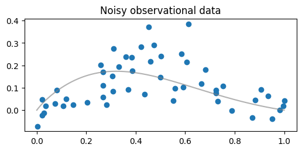

```python
# first, create some noisy observational data
a, L = 1,1
t_time = 0.2
t_obs = torch.rand(200).view(-1,1) # Random time values
x_obs = torch.rand(200).view(-1,1) # Random x values
inputs_obs = torch.cat([x_obs, t_obs], dim=1) # [x,t]

u_obs_exact = exact_solution(a, L, x_obs, t_obs) # Exact u(x,t) solutions for random noise
u_obs = u_obs_exact + 0.001*torch.randn_like(u_obs_exact) # solutions with noise

t_test = torch.linspace(0,t_time,300).view(-1,1) # Time boundary condition
x_test = torch.linspace(0,L,300).view(-1,1) # x coordinate boundary
inputs_test = torch.cat([x_test, t_test], dim=1) # [x,t]

u_exact = exact_solution(a, L,x_test, t_test) # exact solution to u(x,t) with boundary condition

tolerance = 7e-3  # Small tolerance value to see x values for t_time
mask =t_obs <= t_time # Boundary condition for smaller t values than t_time

# Use the mask to filter inputs_obs for graph
filtered_inputs_obs = inputs_obs[mask.squeeze()]  # .squeeze() to remove unnecessary dimensions if needed and get x values for <= t_time
u_obs_exact = exact_solution(a, L, filtered_inputs_obs[:,0], filtered_inputs_obs[:,1]) # calculate u(x,t) for t <= t_time
filtered_u_obs = u_obs_exact + 0.04*torch.randn_like(u_obs_exact) # Add noise to filtered solutions

plt.figure(figsize=(6,2.5))
plt.title("Noisy observational data")
plt.scatter(filtered_inputs_obs[:,0], filtered_u_obs)
plt.plot(x_test, u_exact[:,0], label="Exact solution", color="tab:grey", alpha=0.6)
plt.show()
```

The random noise generated data should follow the line and have some values above the line, but for some reason it's not doing that. The mask works but doesn't cut off at the time $t = 0.2$.

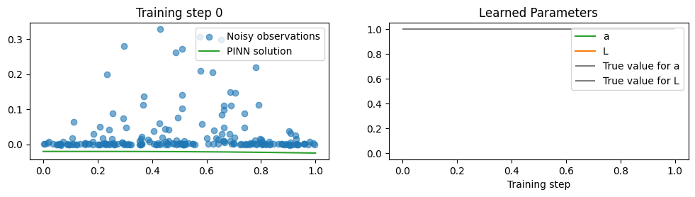

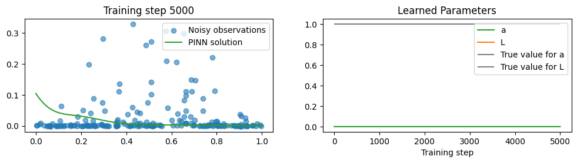

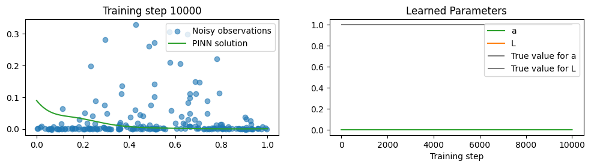

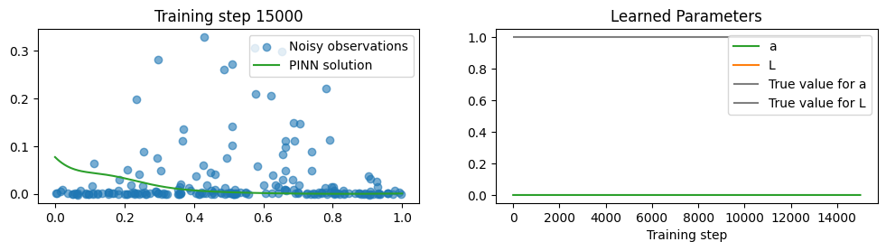

```python
torch.manual_seed(123)

# define a neural network to train
pinn = FCN(2,1,32,3)

# define training points over the entire domain, for the physics loss
t_physics = torch.linspace(0,1,30).view(-1,1).requires_grad_(True)# (30, 1)
x_physics = torch.linspace(0,1,30).view(-1,1).requires_grad_(True)# (30, 1)

# train the PINN
a, L = 1,1
t_test = torch.linspace(0,1,300).view(-1,1)
x_test = torch.linspace(0,1,300).view(-1,1)
inputs_test = torch.cat([x_test, t_test], dim=1)
u_exact = exact_solution(a,L,x_test, t_test)

# treat a as a learnable parameter, add it to optimiser
a = torch.nn.Parameter(torch.zeros(1, requires_grad=True))
L = torch.nn.Parameter(torch.zeros(1, requires_grad=True))
optimiser = torch.optim.Adam(list(pinn.parameters())+[a,L],lr=1e-3)
a_s,L_s = [],[]

for i in range(15001):
    optimiser.zero_grad()

    # compute each term of the PINN loss function above
    # using the following hyperparameters
    lambda1 = 1e4

    # compute physics loss
    x_pde = torch.rand(1000, 1) * L
    t_pde = torch.rand(1000, 1)
    res_pde = pde_residual(pinn, x_pde, t_pde, a)
    loss_pde = loss_fn(res_pde, torch.zeros_like(res_pde))

    # compute data loss
    u = pinn(inputs_obs)
    loss2 = torch.mean((u - u_obs)**2)

    # backpropagate joint loss, take optimiser step
    loss = loss_pde + lambda1*loss2
    loss.backward()
    optimiser.step()

    # record mu value
    a_s.append(a.item())

    # plot the result as training progresses
    if i % 5000 == 0:
        u = pinn(inputs_test).detach()
        plt.figure(figsize=(12,2.5))

        plt.subplot(1,2,1)
        plt.scatter(inputs_obs[:,0], u_obs[:,0], label="Noisy observations", alpha=0.6, color="tab:blue")
        plt.plot(inputs_test[:,0], u[:,0], label="PINN solution", color="tab:green")
        plt.title(f"Training step {i}")
        plt.legend()

        plt.subplot(1, 2, 2)
        plt.title("Learned Parameters")
        plt.plot(a_s, label="a", color="tab:green")
        plt.plot(L_s, label="L", color="tab:orange")
        plt.hlines(1, 0, len(a_s), label="True value for a", color="tab:grey")
        plt.hlines(0, 0, len(L_s), label="True value for L", color="tab:grey")
        plt.xlabel("Training step")
        plt.legend()

        plt.show()
```

The graphs don't look great, because the training data is bad.